# Projeto de Medição

Aline Costa - Rafaelle Amorim - Órion Winter de Lima

### Descrição do sistema

O sistema que decidimos avaliar é um serviço de predição utilizado pelo aplicativo Melhor Busão, aplicativo criado com o intuito de melhorar a experiência dos usuários de transporte público, inicialmente da cidade de Campina Grande - PB e Curitiba - PR.  
O serviço ter como função principal prever a quantidade de passageiros e a duração de uma viagem de ônibus de um dado usuário. Para realizar tal função, o serviço pede os dados da rota do ônibus, parada de início, data e hora da viagem e, através de técnicas de aprendizado de máquina, prevê a quantidade de passageiros e a duração da viagem passada.  
Este serviço está hospedado em um máquina virtual no Laboratório de Sistemas Distribuídos (LSD), localizado na Universidade Federal de Campina Grande (UFCG).

### Objetivo

Decidimos avaliar o sistema quanto ao critério de Escalabilidade, pois é um aspecto de extrema importância no desenvolvimento de sistemas em geral. Em especial para a nossa aplicação, que deverá ser implantada em breve e espera-se que ela consiga trabalhar normalmente mesmo com uma demanda crescente de usuários.  
Para isso, nossa avaliação terá como principal atividade o aumento da quantidade de requisições a que o sistema é submetido e iremos analisar como se comporta o tempo de respostas às requisições diante desse aumento.  
Além da quantidade de requisições, iremos avaliar o impacto da variação da mudança no horário no qual as requisições serão feitas (10hrs e 22hrs, aproximadamente) e se o número de instâncias rodando o serviço pode influenciar na escalabilidade do sistema.

### Especificação de Ambiente

```
Para realizar as medições, vamos utilizar uma máquina de 64 bits, com processador Intel® CoreT i5-3570 CPU @ 3.40GHz × 4, memória de 12GB, rodando em cima do sistema operacional Ubuntu 16.04. A rede que será utilizada na medição tem velocidade declarada de 10 Gbps.
```

### Definição de Métricas

[output not shown]

### Definição de Fatores e Níveis

```
As métricas tempo de resposta de requisição e tempo de resposta da rede serão utilizados para avaliar a escalabilidade do sistema, quando existe variação no número de instâncias rodando, número de requisições e horário das requisições.
```

Os níveis de cada fator serão definidos de acordo com os seguintes valores:

1. Número de Instâncias:
- 1 instância
- 2 instâncias
2. Números de Requisições:
- 10/min
- 40/min
3. Horário das Requisições:
- 10h - 11h
- 22h - 23h

A combinação dos fatores e seus níveis será executada como mostra a tabela abaixo. Realizaremos 3 medições de cada tipo nos horários mencionados durante 3 dias alternados.

| Medição | Instâncias | Requisições/min | Horário |
| --- | --- | --- | --- |
| 1 | 1 | 10 | 10h~11h |
| 2 | 1 | 10 | 22h~23h |
| 3 | 1 | 40 | 10h~11h |
| 4 | 1 | 40 | 22h~23h |
| 5 | 2 | 10 | 10h~11h |
| 6 | 2 | 10 | 22h~23h |
| 7 | 2 | 40 | 10h~11h |
| 8 | 2 | 40 | 22h~23h |

### Experimentos

```
As medições foram feitas a partir de um script nodeJS, o qual realizava a quantidade de requiisições especificadas (10/min e 40/min). Esse script rodou programaticamente através do crontab, um programa nativo do Unix que executa comandos de forma agendada.
```

Inicialmente planejamos os níveis do fator “Números de Requisições” como 100/s e 1000/s. No entanto, percebemos que o serviço não conseguiu responder à todas elas, pois não estava preparado para essa quantidade de requisições. Então, para que fosse possível obter os resultados esperados e analisá-los, testamos a resposta do sistema para outros níveis do fator mencionado e estabelecemos que as quantidades adequadas ao nosso experimento seriam de 10/min e 40/min. A quantidade de instâncias foi modificada manualmente no sistema, de forma que nas primeiras 4 execuções existisse 1 instância disponível e nas 4 seguintes existissem 2 instâncias.

### Resultados

#### Resultados gerais

Abaixo é mostrado o tempo de resposta do sistemas às requisições, sem levar em consideração a variação dos fatores e seus níveis.

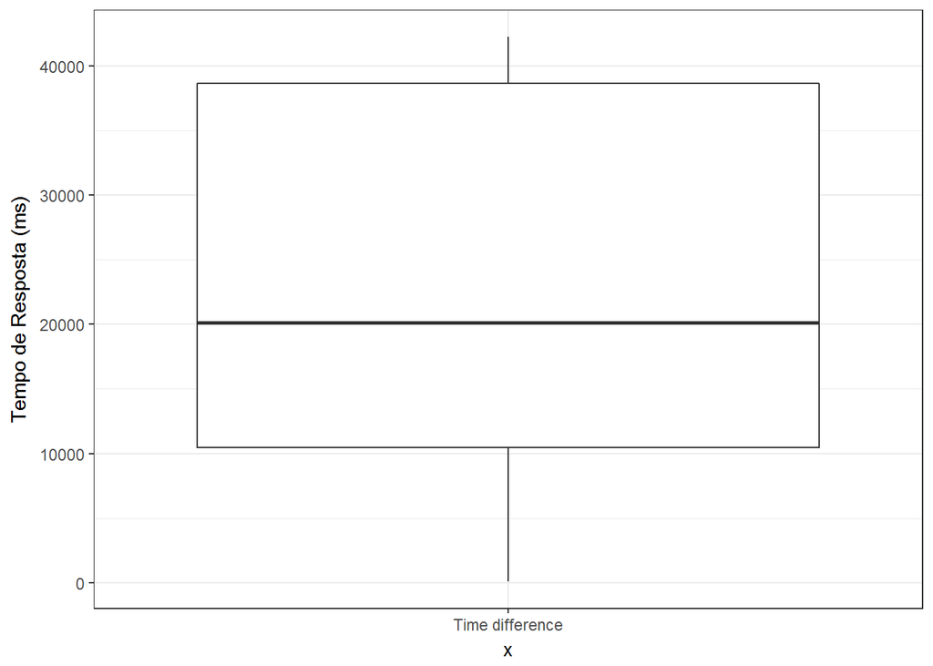

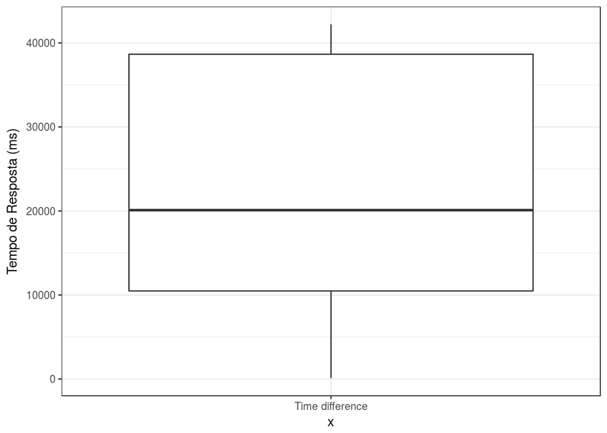

```
##    Min. 1st Qu.  Median    Mean 3rd Qu.    Max.
##     104   10480   20100   23230   38660   42220
```

```
## [1] 13295.31
```

Como é possível ver acima, o tempo de resposta varia bastante. Tendo como média 23,2 segundos, mediana 20,1 segundos e desvio padrão de 13,3 segundos. Os valores do primeiro e terceiro quartil são de 10,5 e 38,7 segundos, os quais se aproxímam bastante do número de requisições por minuto utilizados na medição (10 e 40).

A seguir é possível ver a distribuição destes dados em um Histograma:

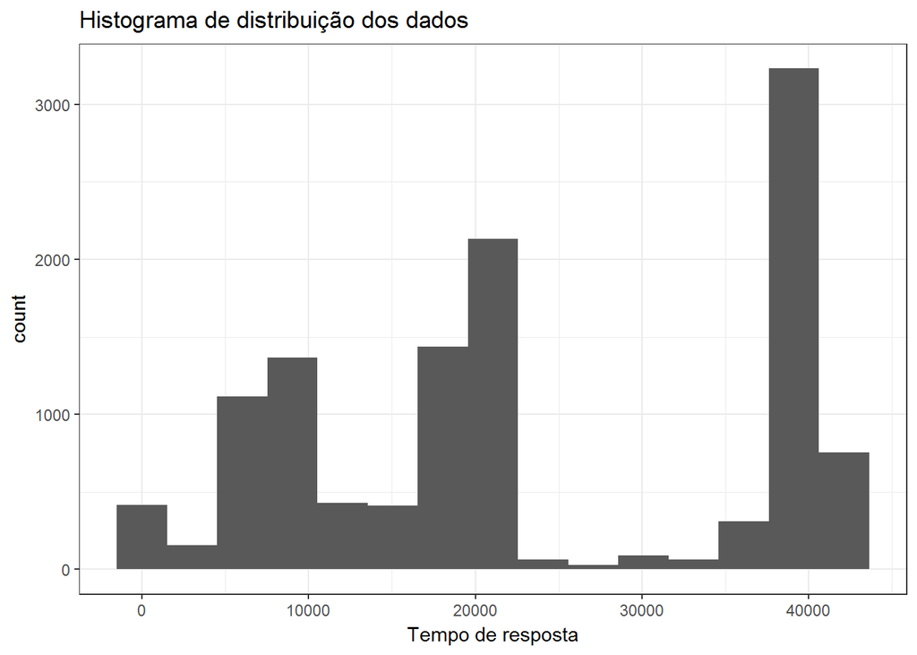

Podemos observar que a distribuição é multimodal, o que pode indicar que os fatores influenciam no tempo de resposta. Para uma maior representação, decidimos utilizar o intervalo de confiança para a média e a mediana.

```
##                     2.5%    97.5%
## mean(time_diff) 22632.76 24338.68
```

```
##                      2.5% 97.5%
## median(time_diff) 19742.5 20495
```

```
## [1] "mean(time_diff)"   "median(time_diff)"
```

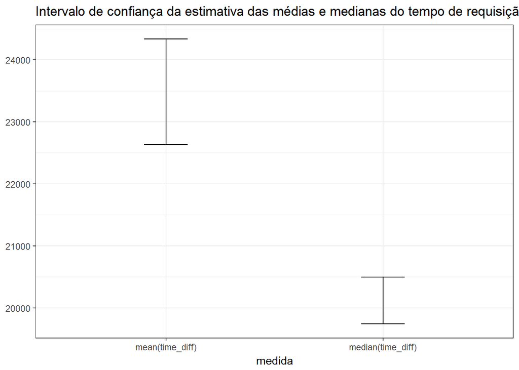

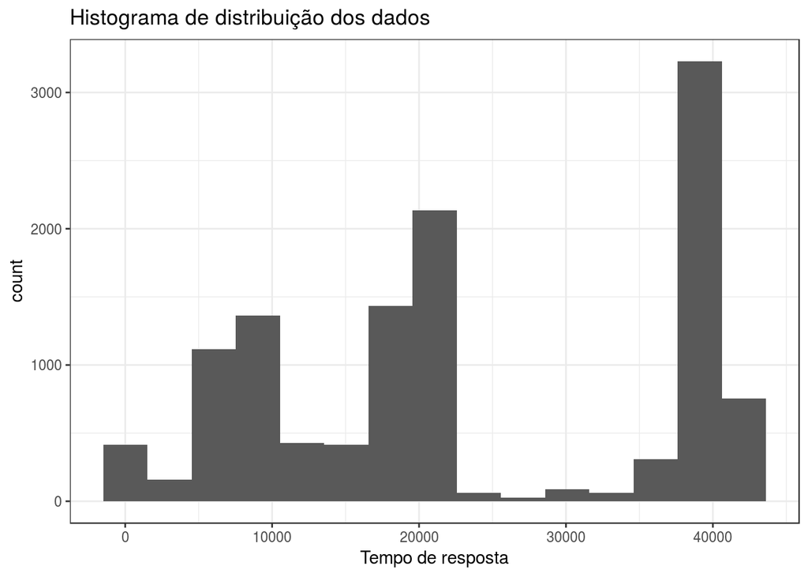

Podemos observar que a distribuição é multimodal, o que pode indicar que os fatores influenciam no tempo de resposta. Para verificar essa hipótese, analisamos os resultados a seguir.

#### Resultados com variação de fatores

Abaixo listamos cada conjunto de fatores analisado. A numeração é utilizada para representar cada grupo de fatores no gráfico seguinte, onde analisamos o tempo de resposta, o comportamento geral, e se existe relação entre os fatores escolhidos.

```
##   Nº de Instâncias Nº de Requisições/min Horário Grupo
## 1                1                    10      10     1
## 2                1                    10      22     2
## 3                1                    40      10     3
## 4                1                    40      22     4
## 5                2                    10      10     5
## 6                2                    10      22     6
## 7                2                    40      10     7
## 8                2                    40      22     8
```

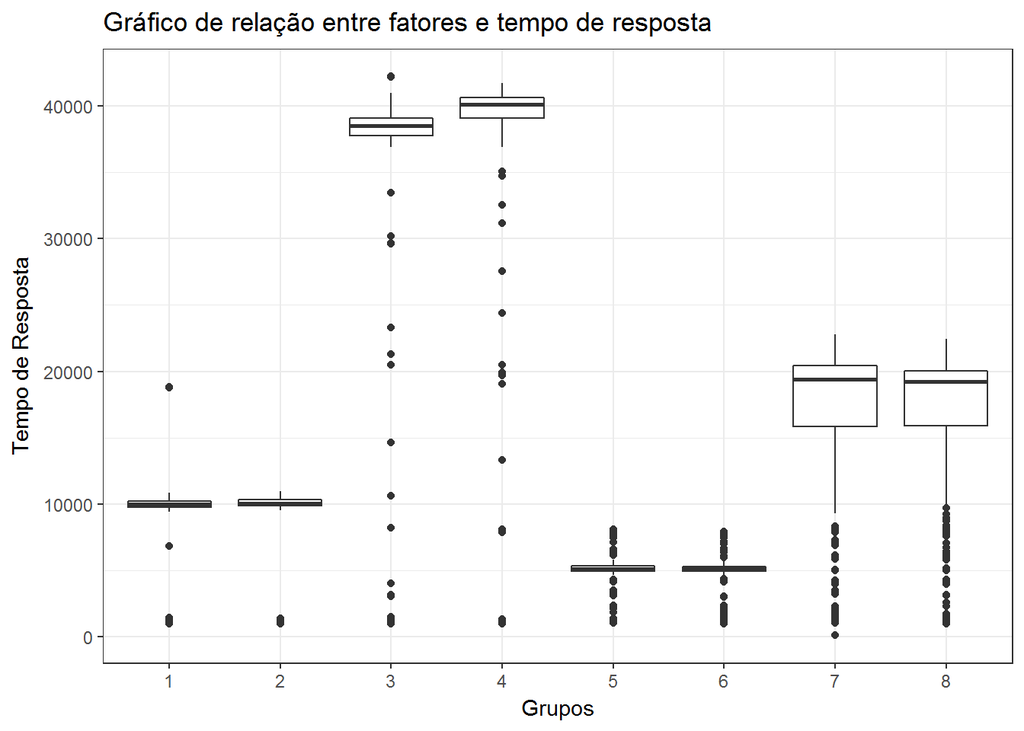

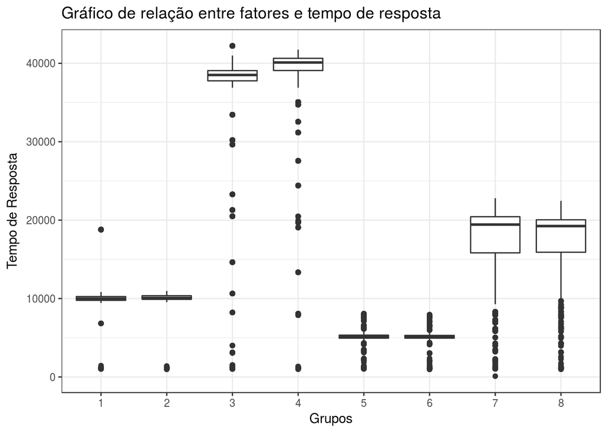

```
## $`1`
##    Min. 1st Qu.  Median    Mean 3rd Qu.    Max.
##    1014    9770    9990    9678   10250   18810
##
## $`2`
##    Min. 1st Qu.  Median    Mean 3rd Qu.    Max.
##     972    9902   10080    9513   10360   10970
##
## $`3`
##    Min. 1st Qu.  Median    Mean 3rd Qu.    Max.
##    1011   37770   38510   36620   39070   42220
##
## $`4`
##    Min. 1st Qu.  Median    Mean 3rd Qu.    Max.
##     982   39080   40100   37700   40630   41740
##
## $`5`
##    Min. 1st Qu.  Median    Mean 3rd Qu.    Max.
##    1030    4947    5129    4879    5334    8080
##
## $`6`
##    Min. 1st Qu.  Median    Mean 3rd Qu.    Max.
##     966    4946    5116    4852    5302    7944
##
## $`7`
##    Min. 1st Qu.  Median    Mean 3rd Qu.    Max.
##     104   15830   19430   17480   20430   22800
##
## $`8`
##    Min. 1st Qu.  Median    Mean 3rd Qu.    Max.
##     982   15910   19250   17150   20050   22460
```

Desvio padrão para cada grupo:

```
##        1        2        3        4        5        6        7        8
## 2813.041 2344.973 7218.549 7476.375 1501.163 1419.078 4838.392 5270.825
```

É possível ver que o número de requisições por minuto é um fator que causa bastante impacto no tempo de resposta, visto que conservando os demais fatores e variando o número de requisições, o tempo de resposta diferencia bastante, como podemos ver nos grupos 1 e 3, 2 e 4, 5 e 7, 6 e 8.

É possível identificar também que o número de instâncias utilizadas na medição influencia bastante o tempo de resposta, visto que fixando os demais fatores e mudando apenas o número de instâncias, o tempo de resposta varia bastante, como pode ser verificado nos grupos 1 e 5, 2 e 6, 3 e 7, 4 e 8.

#### Resultados e análises adicionais

Como análise adicional, vamos verificar como é a distribuição do tempo de resposta, avaliando o número de instâncias, número de requisições e o horário do experimento.

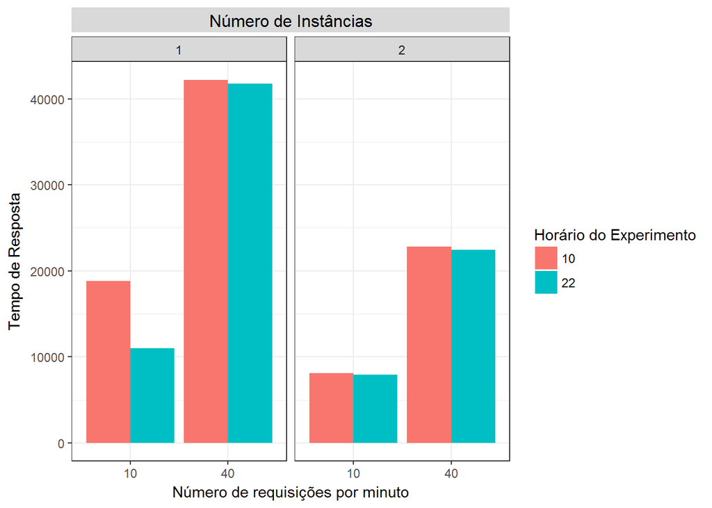

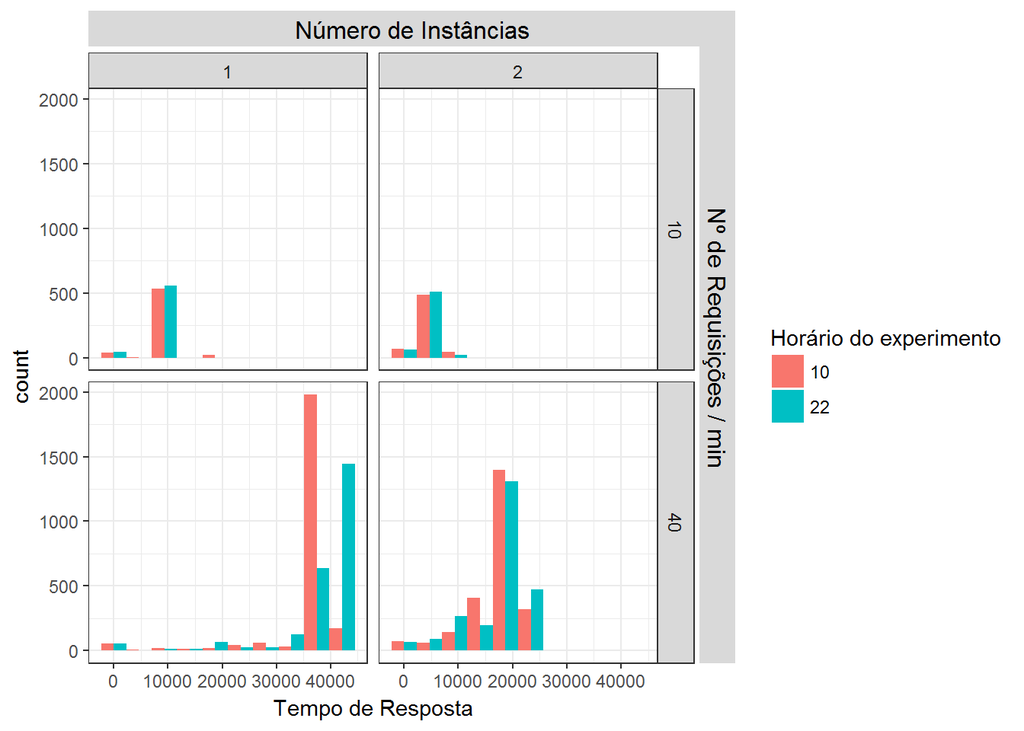

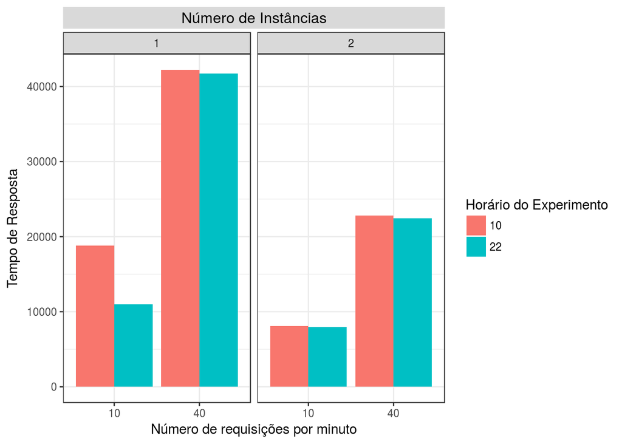

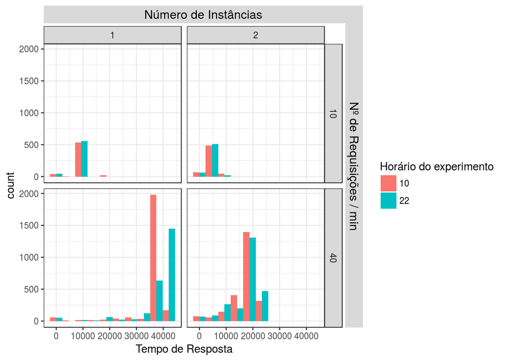

Como já observado anteriormente, o sistema apresenta um tempo de resposta médio bem menor quando a quantidade de requisições por minuto é de 10. E, especialmente para 40 requisições/minuto, o uso de 2 instâncias diminue consideravelmente o tempo de resposta.